# Assignment 1

## Burden By Age

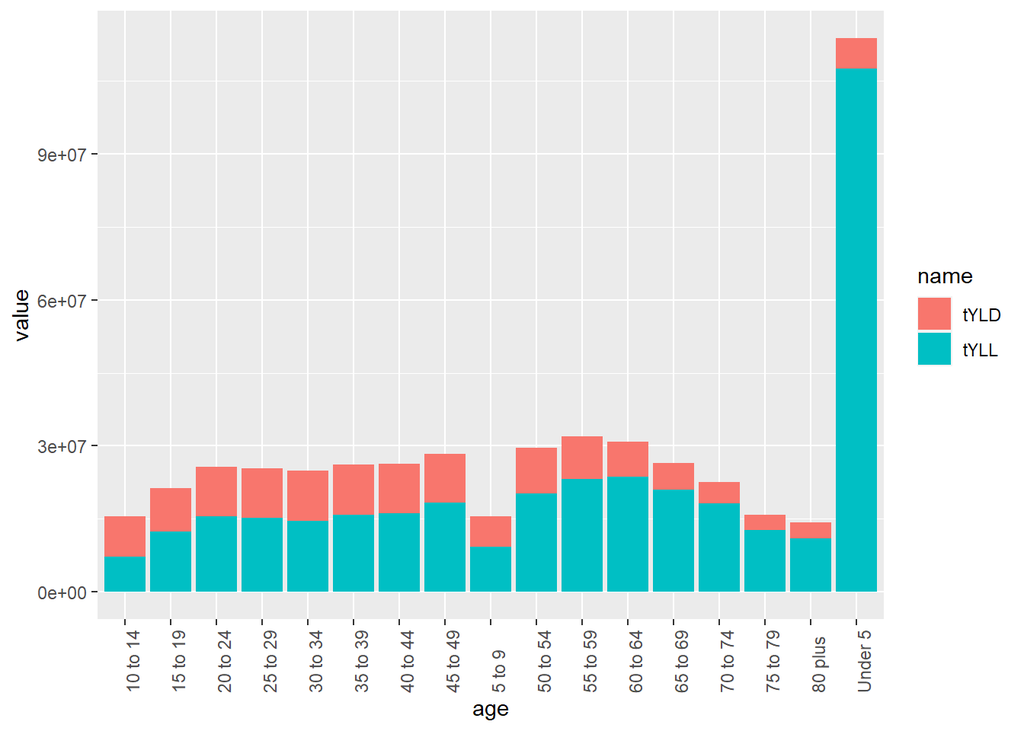

```r
by_age <- deaths %>%
  group_by(age) %>%
  summarize(tDALY = sum(daly), tYLL = sum(yll), tYLD = sum(ylds)) %>%
  pivot_longer(cols = c(tYLL, tYLD))

ggplot(by_age, aes(fill=name, y=value, x=age)) +
    geom_bar(position="stack", stat = "identity") +
  theme(axis.text.x=element_text(angle = 90, hjust = 0))
```

The stacked barplot above shows that the Under 5 age group has by far the biggest aggregate years of life lost, which makes sense because they have the highest life expectancy and many conditions studied hit this age group relatively hard. We can also see that YLLs (and YLDs) decline with life expectancy for older groups. The overall trend in DALYs is that infants are at high risk, then risk is relatively low until adulthood when more disabilities start to come into play.

## By Sex

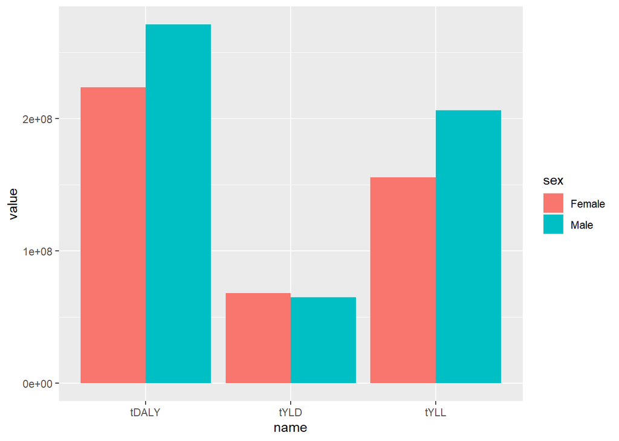

```r
by_sex <- deaths %>%
  group_by(sex) %>%
  summarize(tDALY = sum(daly), tYLL = sum(yll), tYLD = sum(ylds)) %>%
  pivot_longer(cols = c(tYLL, tYLD, tDALY))


ggplot(by_sex, aes(fill=sex, y=value, x=name)) +
    geom_bar(position=position_dodge(), stat = "identity")
```

The chart above shows that males face a higher total impact from DALYs, as well as a noticeably higher total years of life lost. However, we can see that females have a slightly higher total years lived with disability. This would suggest that males tend more towards disabilities with higher mortality rates than women do.